# SI 618 - Homework #6: Machine Learning 1

Version 2023.11.01.1.CT

In this homework exercise you will apply the machine learning techniques we've covered so far: machine learning pipelines, dimension reduction, and clustering.

You will be using the [customer personality analysis dataset](https://www.kaggle.com/datasets/imakash3011/customer-personality-analysis) from Kaggle.

**NOTE:** This is a fairly involved homework assignment and we *strongly* urge you to not leave this to the last minute. We suggest that you try to work on this assignment over several days.

A reminder (from the syllabus):

> Unless stated otherwise in an assignment, you are permitted to use generative AI (e.g. ChatGPT, Copilot, etc.) but you must indicate that you did so in the work that you submit. **If you fail to disclose your use of generative AI you will receive a grade of zero on the assignment**.

### The total score for this assignment will be 100 points, consisting of:

- 10 pt: Overall quality of spelling, grammar, punctuation, etc. of written sentences. ([Guide](https://drive.google.com/file/d/1L0P7xJwjUGBvyb49mL3dw1Bt7hzRTiTl/view))
- 10 pt: Code is written in [PEP 8](https://www.python.org/dev/peps/pep-0008/) style.
- 80 pt: Homework questions.

```python
MY_UNIQNAME = 'sudhagar' # fill this in with your uniqname
```

## Task 1 (10 points):

Perform exploratory data analyses on the variables in this dataset. Your work should include both numerical **and** graphical overviews of the data. Explain your findings.

```python
import pandas as pd
import numpy as np
import matplotlib.pyplot as plt
import seaborn as sns
from sklearn.preprocessing import StandardScaler, OneHotEncoder
from sklearn.model_selection import train_test_split
from sklearn.linear_model import LinearRegression
from sklearn.metrics import mean_squared_error, silhouette_score
from sklearn.decomposition import PCA
from sklearn.cluster import AgglomerativeClustering, KMeans
from sklearn.compose import ColumnTransformer
from sklearn.pipeline import Pipeline
from sklearn.manifold import TSNE
from sklearn.metrics import silhouette_samples, silhouette_score
import warnings

# Ignore all warnings
warnings.filterwarnings('ignore')
```

```python
marketing = pd.read_csv("marketing_campaign.csv", sep='\t')
```

```python
print(marketing.shape)
marketing.sample(5)
```

```
(2240, 29)
```

|  | ID | Year_Birth | Education | Marital_Status | Income | Kidhome | Teenhome | Dt_Customer | Recency | MntWines | ... | NumWebVisitsMonth | AcceptedCmp3 | AcceptedCmp4 | AcceptedCmp5 | AcceptedCmp1 | AcceptedCmp2 | Complain | Z_CostContact | Z_Revenue | Response |
| --- | --- | --- | --- | --- | --- | --- | --- | --- | --- | --- | --- | --- | --- | --- | --- | --- | --- | --- | --- | --- | --- |
| 1840 | 9576 | 1982 | PhD | Together | 32313.0 | 1 | 0 | 11-02-2013 | 60 | 86 | ... | 9 | 0 | 0 | 0 | 0 | 0 | 0 | 3 | 11 | 0 |
| 1545 | 10212 | 1986 | Master | Together | 42386.0 | 1 | 0 | 13-01-2013 | 43 | 65 | ... | 8 | 0 | 0 | 0 | 0 | 0 | 0 | 3 | 11 | 0 |
| 594 | 3075 | 1972 | PhD | Married | 59973.0 | 0 | 0 | 11-09-2013 | 47 | 130 | ... | 1 | 0 | 0 | 0 | 0 | 0 | 0 | 3 | 11 | 0 |
| 668 | 11007 | 1968 | PhD | Married | 29187.0 | 1 | 0 | 09-05-2013 | 43 | 26 | ... | 8 | 0 | 0 | 0 | 0 | 0 | 0 | 3 | 11 | 0 |
| 1232 | 1307 | 1978 | Graduation | Divorced | 41986.0 | 0 | 1 | 09-02-2014 | 15 | 27 | ... | 4 | 0 | 0 | 0 | 0 | 0 | 0 | 3 | 11 | 0 |

5 rows × 29 columns

```python
marketing.info()
```

```
<class 'pandas.core.frame.DataFrame'>
RangeIndex: 2240 entries, 0 to 2239
Data columns (total 29 columns):
 #   Column               Non-Null Count  Dtype
---  ------               --------------  -----
 0   ID                   2240 non-null   int64
 1   Year_Birth           2240 non-null   int64
 2   Education            2240 non-null   object
 3   Marital_Status       2240 non-null   object
 4   Income               2216 non-null   float64
 5   Kidhome              2240 non-null   int64
 6   Teenhome             2240 non-null   int64
 7   Dt_Customer          2240 non-null   object
 8   Recency              2240 non-null   int64
 9   MntWines             2240 non-null   int64
```

[output cut: 21 more lines]

```python
marketing.describe()
```

|  | ID | Year_Birth | Income | Kidhome | Teenhome | Recency | MntWines | MntFruits | MntMeatProducts | MntFishProducts | ... | NumWebVisitsMonth | AcceptedCmp3 | AcceptedCmp4 | AcceptedCmp5 | AcceptedCmp1 | AcceptedCmp2 | Complain | Z_CostContact | Z_Revenue | Response |
| --- | --- | --- | --- | --- | --- | --- | --- | --- | --- | --- | --- | --- | --- | --- | --- | --- | --- | --- | --- | --- | --- |
| count | 2240.000000 | 2240.000000 | 2216.000000 | 2240.000000 | 2240.000000 | 2240.000000 | 2240.000000 | 2240.000000 | 2240.000000 | 2240.000000 | ... | 2240.000000 | 2240.000000 | 2240.000000 | 2240.000000 | 2240.000000 | 2240.000000 | 2240.000000 | 2240.0 | 2240.0 | 2240.000000 |
| mean | 5592.159821 | 1968.805804 | 52247.251354 | 0.444196 | 0.506250 | 49.109375 | 303.935714 | 26.302232 | 166.950000 | 37.525446 | ... | 5.316518 | 0.072768 | 0.074554 | 0.072768 | 0.064286 | 0.013393 | 0.009375 | 3.0 | 11.0 | 0.149107 |
| std | 3246.662198 | 11.984069 | 25173.076661 | 0.538398 | 0.544538 | 28.962453 | 336.597393 | 39.773434 | 225.715373 | 54.628979 | ... | 2.426645 | 0.259813 | 0.262728 | 0.259813 | 0.245316 | 0.114976 | 0.096391 | 0.0 | 0.0 | 0.356274 |
| min | 0.000000 | 1893.000000 | 1730.000000 | 0.000000 | 0.000000 | 0.000000 | 0.000000 | 0.000000 | 0.000000 | 0.000000 | ... | 0.000000 | 0.000000 | 0.000000 | 0.000000 | 0.000000 | 0.000000 | 0.000000 | 3.0 | 11.0 | 0.000000 |
| 25% | 2828.250000 | 1959.000000 | 35303.000000 | 0.000000 | 0.000000 | 24.000000 | 23.750000 | 1.000000 | 16.000000 | 3.000000 | ... | 3.000000 | 0.000000 | 0.000000 | 0.000000 | 0.000000 | 0.000000 | 0.000000 | 3.0 | 11.0 | 0.000000 |
| 50% | 5458.500000 | 1970.000000 | 51381.500000 | 0.000000 | 0.000000 | 49.000000 | 173.500000 | 8.000000 | 67.000000 | 12.000000 | ... | 6.000000 | 0.000000 | 0.000000 | 0.000000 | 0.000000 | 0.000000 | 0.000000 | 3.0 | 11.0 | 0.000000 |
| 75% | 8427.750000 | 1977.000000 | 68522.000000 | 1.000000 | 1.000000 | 74.000000 | 504.250000 | 33.000000 | 232.000000 | 50.000000 | ... | 7.000000 | 0.000000 | 0.000000 | 0.000000 | 0.000000 | 0.000000 | 0.000000 | 3.0 | 11.0 | 0.000000 |
| max | 11191.000000 | 1996.000000 | 666666.000000 | 2.000000 | 2.000000 | 99.000000 | 1493.000000 | 199.000000 | 1725.000000 | 259.000000 | ... | 20.000000 | 1.000000 | 1.000000 | 1.000000 | 1.000000 | 1.000000 | 1.000000 | 3.0 | 11.0 | 1.000000 |

8 rows × 26 columns

```python
marketing.isna().any()
```

```
ID                     False
Year_Birth             False
Education              False
Marital_Status         False
Income                  True
Kidhome                False
Teenhome               False
Dt_Customer            False
Recency                False
MntWines               False
MntFruits              False
MntMeatProducts        False
MntFishProducts        False
MntSweetProducts       False
MntGoldProds           False
NumDealsPurchases      False
NumWebPurchases        False
NumCatalogPurchases    False
NumStorePurchases      False
NumWebVisitsMonth      False
AcceptedCmp3           False
AcceptedCmp4           False
AcceptedCmp5           False
AcceptedCmp1           False
AcceptedCmp2           False
Complain               False
Z_CostContact          False
Z_Revenue              False
Response               False
dtype: bool
```

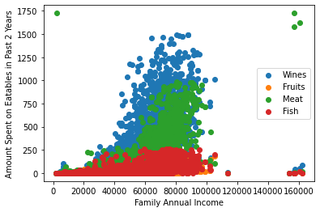

```python
# Filtering the dataframe for incomes less than 500000
filtered_data = marketing[marketing['Income'] < 500000]

plt.scatter(
    filtered_data['Income'], filtered_data['MntWines'], label='Wines'
)
plt.scatter(
    filtered_data['Income'], filtered_data['MntFruits'], label='Fruits'
)
plt.scatter(
    filtered_data['Income'], filtered_data['MntMeatProducts'], label='Meat'
)
plt.scatter(
    filtered_data['Income'], filtered_data['MntFishProducts'], label='Fish'
)

plt.xlabel("Family Annual Income")
plt.ylabel("Amount Spent on Eatables in Past 2 Years")
plt.legend()

plt.show()
```

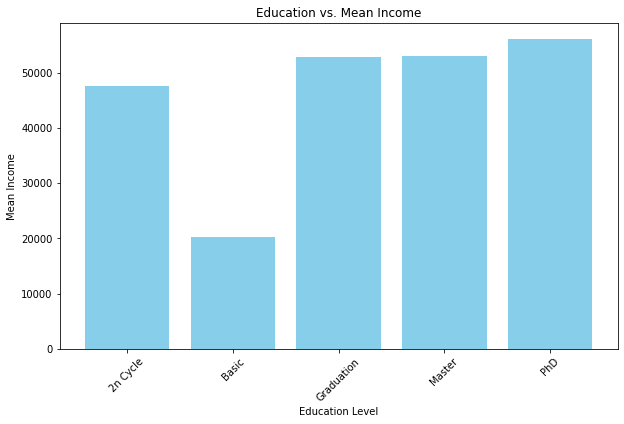

```python
education_income_mean = marketing.groupby('Education')['Income'].mean()

unique_education_levels = education_income_mean.index

# Create a bar plot (histogram) for education vs. mean income
plt.figure(figsize=(10, 6))
plt.bar(unique_education_levels, education_income_mean, color='skyblue')
plt.title("Education vs. Mean Income")
plt.xlabel("Education Level")
plt.ylabel("Mean Income")
plt.xticks(rotation=45)
plt.show()
```

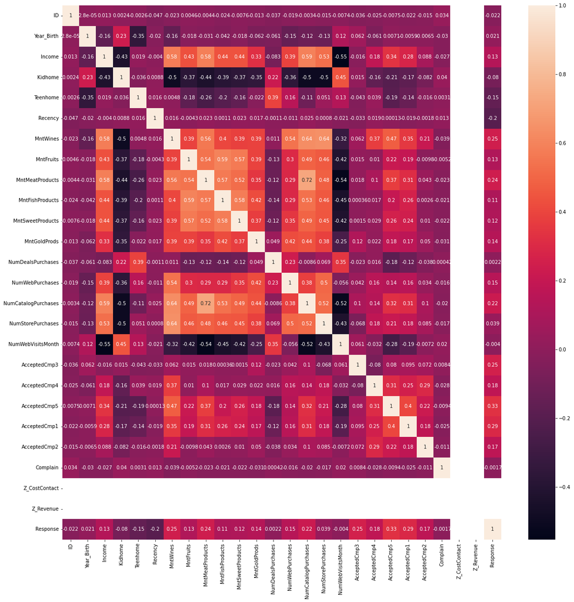

```python
plt.figure(figsize=(20,20))
sns.heatmap(marketing.corr(numeric_only=True), annot=True)
plt.show()
```

### Heatmap Interpretation -

**Strong Positive Correlation Example:** There is a strong positive correlation (0.58) between 'MntMeatProducts' and 'Income', indicating these variables tend to increase together.

**Strong Negative Correlation Example:** Conversely, there is a strong negative correlation (-0.5) between 'NumStorePurchases' & 'Kidhome', suggesting an inverse relationship between these variables.

## Task 2 (1 point): Drop all columns that have constant values.

Checking for columns with constant values -

```python
def find_constant_columns(dataframe):
    constant_columns = [col for col in dataframe.columns if dataframe[col].nunique() == 1]
    return constant_columns

# Find and print constant columns
constant_cols = find_constant_columns(marketing)
constant_cols
```

```
['Z_CostContact', 'Z_Revenue']
```

Dropping those columns from the dataframe -

```python
# Dropping the constant columns
marketing_updated = marketing.drop(columns=constant_cols)
marketing_updated.sample(5)
```

|  | ID | Year_Birth | Education | Marital_Status | Income | Kidhome | Teenhome | Dt_Customer | Recency | MntWines | ... | NumCatalogPurchases | NumStorePurchases | NumWebVisitsMonth | AcceptedCmp3 | AcceptedCmp4 | AcceptedCmp5 | AcceptedCmp1 | AcceptedCmp2 | Complain | Response |
| --- | --- | --- | --- | --- | --- | --- | --- | --- | --- | --- | --- | --- | --- | --- | --- | --- | --- | --- | --- | --- | --- |
| 2238 | 8235 | 1956 | Master | Together | 69245.0 | 0 | 1 | 24-01-2014 | 8 | 428 | ... | 5 | 10 | 3 | 0 | 0 | 0 | 0 | 0 | 0 | 0 |
| 518 | 4607 | 1959 | Graduation | Together | 71367.0 | 0 | 0 | 23-08-2013 | 24 | 227 | ... | 5 | 7 | 2 | 0 | 0 | 0 | 0 | 0 | 0 | 0 |
| 83 | 4119 | 1963 | Master | Together | 38620.0 | 0 | 0 | 11-05-2013 | 56 | 112 | ... | 5 | 3 | 3 | 0 | 0 | 0 | 0 | 0 | 0 | 0 |
| 1509 | 10128 | 1958 | Graduation | Together | 53977.0 | 0 | 1 | 08-06-2013 | 21 | 620 | ... | 5 | 12 | 5 | 0 | 0 | 0 | 0 | 0 | 0 | 0 |
| 1158 | 7959 | 1961 | Graduation | Married | 79410.0 | 0 | 0 | 29-05-2014 | 19 | 658 | ... | 2 | 5 | 1 | 0 | 0 | 0 | 0 | 0 | 0 | 0 |

5 rows × 27 columns

```python
marketing_updated['Age']=2023-marketing_updated['Year_Birth']
#Dropping the columns 'ID', 'Year_Birth', 'Dt_Customer'
marketing_updated.drop(['ID','Year_Birth','Dt_Customer'], axis=1, inplace=True)
marketing_updated.sample(5)
```

|  | Education | Marital_Status | Income | Kidhome | Teenhome | Recency | MntWines | MntFruits | MntMeatProducts | MntFishProducts | ... | NumStorePurchases | NumWebVisitsMonth | AcceptedCmp3 | AcceptedCmp4 | AcceptedCmp5 | AcceptedCmp1 | AcceptedCmp2 | Complain | Response | Age |
| --- | --- | --- | --- | --- | --- | --- | --- | --- | --- | --- | --- | --- | --- | --- | --- | --- | --- | --- | --- | --- | --- |
| 1789 | Graduation | Together | 77298.0 | 0 | 1 | 46 | 425 | 115 | 292 | 23 | ... | 11 | 3 | 0 | 0 | 0 | 0 | 0 | 0 | 0 | 44 |
| 1596 | Master | Together | 17144.0 | 1 | 1 | 96 | 18 | 2 | 19 | 0 | ... | 4 | 7 | 0 | 0 | 0 | 0 | 0 | 0 | 0 | 63 |
| 286 | Graduation | Together | 75278.0 | 0 | 0 | 17 | 304 | 98 | 230 | 150 | ... | 13 | 3 | 0 | 0 | 0 | 0 | 0 | 0 | 0 | 71 |
| 1339 | Graduation | Single | 39660.0 | 1 | 0 | 36 | 139 | 13 | 78 | 20 | ... | 3 | 9 | 0 | 0 | 0 | 0 | 0 | 0 | 1 | 41 |
| 697 | PhD | Single | 26518.0 | 1 | 1 | 33 | 20 | 1 | 28 | 3 | ... | 3 | 8 | 0 | 0 | 0 | 0 | 0 | 0 | 1 | 74 |

5 rows × 25 columns

### Task 2 Interpretation -

- The solution identifies and removes columns from the dataset that have constant values, which in this case are 'Z_CostContact' and 'Z_Revenue'. Removing these columns is beneficial because constant features do not provide any informative variance for statistical models and can unnecessarily increase computational complexity.
- This cleanup step is a good practice in data preprocessing to ensure that the remaining dataset features are potentially relevant for further analysis or modeling.

## Task 3 (1 point):

Create a new variable `In_Relationship` whose value is 1 if the value of `Marital_Status` is "Married" or "Together" and 0 otherwise. Drop the `Marital_Status` column.

```python
marketing_updated['In_Relationship'] = marketing_updated['Marital_Status'].apply(lambda status: 1 if status in ["Married", "Together"] else 0)

# Dropping the 'Marital_Status' column
marketing_updated = marketing_updated.drop(columns=['Marital_Status'])
```

```python
marketing_updated.sample(5)
```

|  | Education | Income | Kidhome | Teenhome | Recency | MntWines | MntFruits | MntMeatProducts | MntFishProducts | MntSweetProducts | ... | NumWebVisitsMonth | AcceptedCmp3 | AcceptedCmp4 | AcceptedCmp5 | AcceptedCmp1 | AcceptedCmp2 | Complain | Response | Age | In_Relationship |
| --- | --- | --- | --- | --- | --- | --- | --- | --- | --- | --- | --- | --- | --- | --- | --- | --- | --- | --- | --- | --- | --- |
| 1425 | Graduation | 28164.0 | 1 | 0 | 23 | 3 | 18 | 26 | 11 | 8 | ... | 7 | 0 | 0 | 0 | 0 | 0 | 0 | 0 | 53 | 1 |
| 1907 | Graduation | 33235.0 | 1 | 0 | 71 | 45 | 0 | 16 | 2 | 1 | ... | 7 | 0 | 0 | 0 | 0 | 0 | 0 | 0 | 37 | 1 |
| 835 | Graduation | 71391.0 | 0 | 1 | 50 | 336 | 123 | 274 | 46 | 123 | ... | 3 | 0 | 0 | 0 | 0 | 0 | 0 | 0 | 67 | 1 |
| 1398 | Master | 63841.0 | 0 | 1 | 64 | 635 | 15 | 100 | 20 | 7 | ... | 6 | 0 | 0 | 0 | 0 | 0 | 0 | 0 | 55 | 0 |
| 697 | PhD | 26518.0 | 1 | 1 | 33 | 20 | 1 | 28 | 3 | 3 | ... | 8 | 0 | 0 | 0 | 0 | 0 | 0 | 1 | 74 | 0 |

5 rows × 25 columns

### Task 3 Interpretation -

- The solution above successfully creates a binary indicator variable named 'In_Relationship' that categorizes individuals as either being in a relationship (1) or not (0), based on their Marital_Status.
- By dropping the Marital_Status column after this transformation, we simplify the dataset and potentially reduce dimensionality for future analyses, focusing solely on the relationship status as a binary feature.

## Task 4 (3 points):

Impute missing income values with the median income. Explain your results (i.e. what the median value was, how many values were imputed, how reliable you think the median value is, etc.).

```python
# Checking the number of missing values in 'Income'
missing_income_before = marketing_updated['Income'].isna().sum()
print(f"Number of missing 'Income' values before imputation: {missing_income_before}")

# Calculating the median income
median_income = marketing_updated['Income'].median()
print(f"Median 'Income': {median_income}")

# Imputing missing 'Income' values with the median income
marketing_updated['Income'].fillna(median_income, inplace=True)

# Checking the number of missing values in 'Income' after imputation
missing_income_after = marketing_updated['Income'].isna().sum()
print(f"Number of missing 'Income' values after imputation: {missing_income_after}")
```

```
Number of missing 'Income' values before imputation: 24
Median 'Income': 51381.5
Number of missing 'Income' values after imputation: 0
```

### Task 4 Interpretation -

- Using the median to fill in missing data is a preferred strategy as it's more robust to extreme values compared to the average. This makes the median a potentially more accurate reflection of the 'Income' distribution center. Nonetheless, this approach has its drawbacks; it diminishes the diversity of the income data and can lead to skewed results, particularly when missing entries are numerous.

## Task 5 (15 points):

Use scikit-learn to conduct a linear regression that models the amount spend on wine (`MntWines`) based on `Income` and whether they are in a relationship (`In_Relationship`). Assess how good your model is by reporting the root mean squared error (RMSE) using the test dataset from an 80-20 train-test-split of the original dataset. Explain what your value of RMSE means, and comment on how good you think your model is based on the RMSE value means.

```python
np.random.seed(0)

X = marketing_updated[['Income', 'In_Relationship']]
y = marketing_updated['MntWines']

# Splitting the dataset
X_train, X_test, y_train, y_test = train_test_split(X, y, test_size=0.2, random_state=42)

regressor = LinearRegression()

# Fit the model using the training data
regressor.fit(X_train, y_train)

y_pred = regressor.predict(X_test)

# Calculate the RMSE
rmse = np.sqrt(mean_squared_error(y_test, y_pred))

print(f"The RMSE is {rmse}")
```

```
The RMSE is 263.61704688252826
```

### Task 5 Interpretation -

- An RMSE value of 263.617 suggests that the typical prediction by the linear regression model of wine spending deviates from the actual spending by approximately $263.62.
- The interpretation of RMSE is scale-dependent, meaning that its significance is relative to the actual amounts spent on wine. If typical spending values are in the thousands, then an RMSE of 263 may be considered small, but if typical spending is lower, this error might be quite significant.
- If the variability (i.e., the range or standard deviation) of 'MntWines' spending is large, an RMSE of 263 might indicate that the model captures the general trend despite the data's inherent variability. Conversely, if 'MntWines' has low variability, an RMSE of this size could suggest the model is not performing well.

## Task 6 (20 points):

Conduct an agglomerative clustering analysis to find 4 clusters using average linkage based on PCA projections of the original data onto 5 dimensions (use one-hot encoding on your categorical variables, and remember to scale your data before doing the PCA). Report the percentage of variance retained in the first 5 principal components.

Do not create a dendrogram. Instead, create a scatterplot of the first two principal components, colored by cluster membership. Comment on the results of your clustering analysis.

Repeat the above steps using 7 clusters. Compare the results to the 4 cluster solution. Which solution do you prefer and why?

Keep in mind that one of the goals of cluster analysis with this dataset is creating customer segments. Can you define customer segments by examining the characteristics of each cluster? (Hint: a groupby() by cluster membership might be helpful here.)

```python
categorical_cols = marketing_updated.select_dtypes(include=['object', 'category']).columns
numeric_cols = marketing_updated.columns.difference(categorical_cols)


numeric_transformer = Pipeline([
    ('scaler', StandardScaler())
])

categorical_transformer = Pipeline([
    ('onehot', OneHotEncoder(sparse_output=False))
])

preprocessor=ColumnTransformer(
    transformers=[
    ('num', numeric_transformer, numeric_cols),
    ('cat', categorical_transformer, categorical_cols)
    ])

# Create the PCA pipeline
pca = Pipeline([
    ('preprocessor', preprocessor),
    ('pca', PCA(n_components=5))
])

#Fit and transform the data using the PCA pipeline
X_pca = pca.fit_transform(marketing_updated)
```

```python
explained_variance_ratio = pca.named_steps['pca'].explained_variance_ratio_
explained_variance = np.sum(explained_variance_ratio) * 100
print(f"Percentage of variance retained in the first 5 principal components: {explained_variance:.2f}%")
```

```
Percentage of variance retained in the first 5 principal components: 52.64%
```

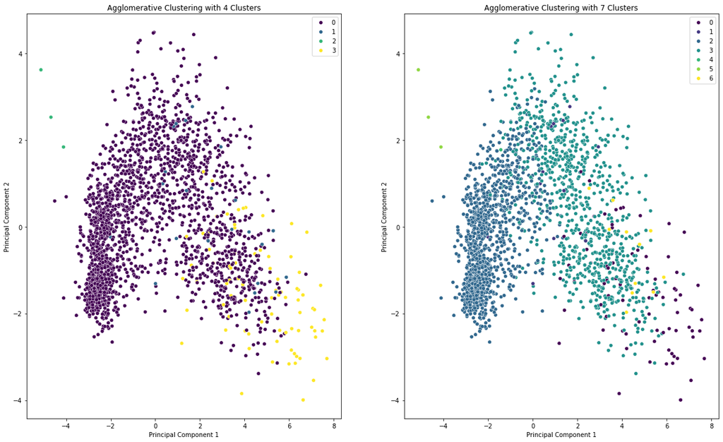

```python
# Agglomerative Clustering model with 4 clusters and average linkage
cluster_model_4 = AgglomerativeClustering(n_clusters=4, linkage='average')
cluster_labels_4 = cluster_model_4.fit_predict(X_pca)
marketing_updated['Clusters_4']=cluster_labels_4

# Agglomerative Clustering model with 7 clusters and average linkage
cluster_model_7 = AgglomerativeClustering(n_clusters=7, linkage='average')
cluster_labels_7 = cluster_model_7.fit_predict(X_pca)
marketing_updated['Clusters_7']=cluster_labels_7

# scatterplot of the first two principal components
plt.figure(figsize=(20, 12))
plt.subplot(1,2,1)
sns.scatterplot(x=X_pca[:, 0], y=X_pca[:, 1], hue=cluster_labels_4, palette='viridis', legend='full')
plt.title('Agglomerative Clustering with 4 Clusters')
plt.xlabel('Principal Component 1')
plt.ylabel('Principal Component 2')
# plt.show()

# Scatterplot of the first two principal components
# plt.figure(figsize=(10, 6))
plt.subplot(1,2,2)
sns.scatterplot(x=X_pca[:, 0], y=X_pca[:, 1], hue=cluster_labels_7, palette='viridis', legend='full')
plt.title('Agglomerative Clustering with 7 Clusters')
plt.xlabel('Principal Component 1')
plt.ylabel('Principal Component 2')
plt.show()
```

```python
# Group by cluster to create customer segments
segments4 = marketing_updated.drop('Clusters_7', axis=1).groupby('Clusters_4')
segments4.describe().T
```

|  | Clusters_4 | 0 | 1 | 2 | 3 |
| --- | --- | --- | --- | --- | --- |
| Income | count | 2123.000000 | 28.000000 | 3.000000 | 86.000000 |
|  | mean | 50902.639425 | 66839.142857 | 4593.666667 | 82110.284884 |
|  | std | 24693.941971 | 16094.468527 | 3187.545503 | 10476.712717 |
|  | min | 2447.000000 | 37929.000000 | 1730.000000 | 49118.000000 |
|  | 25% | 34616.500000 | 55212.000000 | 2876.500000 | 76854.000000 |
| ... | ... | ... | ... | ... | ... |
| In_Relationship | min | 0.000000 | 0.000000 | 0.000000 | 0.000000 |
|  | 25% | 0.000000 | 0.000000 | 0.000000 | 0.000000 |
|  | 50% | 1.000000 | 1.000000 | 0.000000 | 1.000000 |
|  | 75% | 1.000000 | 1.000000 | 0.500000 | 1.000000 |
|  | max | 1.000000 | 1.000000 | 1.000000 | 1.000000 |

192 rows × 4 columns

```python
for name, group in segments4:
    print(f"Segment 4: Cluster {name}")
    print(group.describe())
```

```
Segment 4: Cluster 0
              Income      Kidhome     Teenhome      Recency     MntWines  \
count    2123.000000  2123.000000  2123.000000  2123.000000  2123.000000
mean    50902.639425     0.464437     0.523316    49.172869   273.406029
std     24693.941971     0.542303     0.545566    29.034118   304.975091
min      2447.000000     0.000000     0.000000     0.000000     0.000000
25%     34616.500000     0.000000     0.000000    24.000000    22.000000
50%     50334.000000     0.000000     0.000000    49.000000   159.000000
75%     66323.500000     1.000000     1.000000    74.000000   452.500000
max    666666.000000     2.000000     2.000000    99.000000  1449.000000

         MntFruits  MntMeatProducts  MntFishProducts  MntSweetProducts  \
count  2123.000000      2123.000000      2123.000000       2123.000000
mean     24.951013       154.650966        35.919925         25.579840
std      38.230469       214.493198        53.344294         39.876324
min       0.000000         0.000000         0.000000          0.000000
25%       1.000000        15.000000         3.000000          1.000000
50%       7.000000        59.000000        11.000000          8.000000
75%      31.000000       210.500000        46.000000         30.500000
max     199.000000      1725.000000       259.000000        263.000000

       MntGoldProds  ...  AcceptedCmp3  AcceptedCmp4  AcceptedCmp5  \
count   2123.000000  ...   2123.000000   2123.000000   2123.000000
mean      42.295337  ...      0.067358      0.043335      0.034856
std       50.734491  ...      0.250699      0.203658      0.183459
min        0.000000  ...      0.000000      0.000000      0.000000
25%        8.000000  ...      0.000000      0.000000      0.000000
50%       23.000000  ...      0.000000      0.000000      0.000000
75%       54.000000  ...      0.000000      0.000000      0.000000
max      362.000000  ...      1.000000      1.000000      1.000000

       AcceptedCmp1  AcceptedCmp2     Complain     Response          Age  \
count   2123.000000        2123.0  2123.000000  2123.000000  2123.000000
mean       0.036269           0.0     0.009892     0.121055    54.266604
std        0.187004           0.0     0.098987     0.326268    11.911294
min        0.000000           0.0     0.000000     0.000000    27.000000
25%        0.000000           0.0     0.000000     0.000000    46.000000
50%        0.000000           0.0     0.000000     0.000000    53.000000
75%        0.000000           0.0     0.000000     0.000000    64.000000
max        1.000000           0.0     1.000000     1.000000   130.000000
```

[output cut: 133 more lines]

```
50%        1.000000      0.000000       0.0   1.000000  49.000000
75%        1.000000      0.000000       0.0   1.000000  64.750000
max        1.000000      1.000000       0.0   1.000000  77.000000

       In_Relationship  Clusters_4
count        86.000000        86.0
mean          0.709302         3.0
std           0.456748         0.0
min           0.000000         3.0
25%           0.000000         3.0
50%           1.000000         3.0
75%           1.000000         3.0
max           1.000000         3.0

[8 rows x 25 columns]
```

```python
# Group by cluster to create customer segments
segments7 = marketing_updated.drop('Clusters_4', axis=1).groupby('Clusters_7')
segments7.describe().T
```

|  | Clusters_7 | 0 | 1 | 2 | 3 | 4 | 5 | 6 |
| --- | --- | --- | --- | --- | --- | --- | --- | --- |
| Income | count | 86.000000 | 15.000000 | 1222.000000 | 899.000000 | 2.000000 | 3.000000 | 13.000000 |
|  | mean | 82110.284884 | 56812.466667 | 38073.898118 | 68346.137931 | 48411.000000 | 4593.666667 | 78408.384615 |
|  | std | 10476.712717 | 11332.115210 | 15373.860693 | 24304.121204 | 16646.707843 | 3187.545503 | 12740.999853 |
|  | min | 49118.000000 | 37929.000000 | 3502.000000 | 2447.000000 | 36640.000000 | 1730.000000 | 48192.000000 |
|  | 25% | 76854.000000 | 48381.000000 | 27613.250000 | 59633.500000 | 42525.500000 | 2876.500000 | 71670.000000 |
| ... | ... | ... | ... | ... | ... | ... | ... | ... |
| In_Relationship | min | 0.000000 | 0.000000 | 0.000000 | 0.000000 | 0.000000 | 0.000000 | 0.000000 |
|  | 25% | 0.000000 | 0.000000 | 0.000000 | 0.000000 | 0.000000 | 0.000000 | 0.000000 |
|  | 50% | 1.000000 | 1.000000 | 1.000000 | 1.000000 | 0.000000 | 0.000000 | 1.000000 |
|  | 75% | 1.000000 | 1.000000 | 1.000000 | 1.000000 | 0.000000 | 0.500000 | 1.000000 |
|  | max | 1.000000 | 1.000000 | 1.000000 | 1.000000 | 0.000000 | 1.000000 | 1.000000 |

192 rows × 7 columns

```python
for name, group in segments7:
    print(f"Segment 4: Cluster {name}")
    print(group.describe().T)
```

```
Segment 4: Cluster 0
                     count          mean           std      min       25%  \
Income                86.0  82110.284884  10476.712717  49118.0  76854.00
Kidhome               86.0      0.069767      0.256249      0.0      0.00
Teenhome              86.0      0.069767      0.256249      0.0      0.00
Recency               86.0     48.720930     26.923705      2.0     26.25
MntWines              86.0    884.697674    335.634783     32.0    706.00
MntFruits             86.0     64.837209     59.171706      0.0     21.00
MntMeatProducts       86.0    476.825581    293.504753     48.0    241.50
MntFishProducts       86.0     80.325581     71.144499      0.0     23.00
MntSweetProducts      86.0     66.872093     56.923849      0.0     20.25
MntGoldProds          86.0     85.127907     68.750666      0.0     27.75
NumDealsPurchases     86.0      0.953488      0.592244      0.0      1.00
NumWebPurchases       86.0      5.267442      2.099997      0.0      4.00
NumCatalogPurchases   86.0      6.127907      2.533524      0.0      4.00
NumStorePurchases     86.0      7.941860      2.697950      1.0      6.00
NumWebVisitsMonth     86.0      2.941860      2.025454      0.0      1.25
AcceptedCmp3          86.0      0.197674      0.400581      0.0      0.00
AcceptedCmp4          86.0      0.593023      0.494152      0.0      0.00
AcceptedCmp5          86.0      0.883721      0.322439      0.0      1.00
AcceptedCmp1          86.0      0.639535      0.482951      0.0      0.00
AcceptedCmp2          86.0      0.069767      0.256249      0.0      0.00
Complain              86.0      0.000000      0.000000      0.0      0.00
Response              86.0      0.686047      0.466820      0.0      0.00
Age                   86.0     51.651163     13.794089     30.0     41.00
In_Relationship       86.0      0.709302      0.456748      0.0      0.00
Clusters_7            86.0      0.000000      0.000000      0.0      0.00

                         50%       75%       max
Income               82171.5  89663.50  105471.0
Kidhome                  0.0      0.00       1.0
Teenhome                 0.0      0.00       1.0
Recency                 49.0     72.00      95.0
MntWines               923.5   1111.00    1493.0
MntFruits               34.0    118.50     185.0
MntMeatProducts        430.0    734.00    1607.0
MntFishProducts         60.5    118.00     246.0
MntSweetProducts        45.0     99.50     194.0
MntGoldProds            62.5    129.75     245.0
NumDealsPurchases        1.0      1.00       3.0
```

[output cut: 323 more lines]

```
NumDealsPurchases        1.0      1.0      3.0
NumWebPurchases          5.0      6.0     11.0
NumCatalogPurchases      6.0      9.0     10.0
NumStorePurchases        9.0     12.0     12.0
NumWebVisitsMonth        5.0      6.0      8.0
AcceptedCmp3             0.0      0.0      0.0
AcceptedCmp4             1.0      1.0      1.0
AcceptedCmp5             1.0      1.0      1.0
AcceptedCmp1             1.0      1.0      1.0
AcceptedCmp2             1.0      1.0      1.0
Complain                 0.0      0.0      0.0
Response                 1.0      1.0      1.0
Age                     62.0     65.0     69.0
In_Relationship          1.0      1.0      1.0
Clusters_7               6.0      6.0      6.0
```

### Task 6 Interpretation -

**Inference of segments in 4-cluster agglomerative clustering:**

**7-Cluster Scatterplot Interpretation:**

- Increasing the number of clusters to 7 results in a finer subdivision of the data. This could be beneficial if the underlying structure of the data is complex, but it also increases the risk of overfitting, where clusters may not represent meaningful separations in the original data space.
- The additional clusters (especially clusters 4, 5, and 6) are less distinct from one another, which could indicate that the separation of data points is more nuanced and not as pronounced as in the 4-cluster solution.
- The increased granularity might be reflecting subtle groupings within the larger clusters identified in the 4-cluster solution, which could be important if those nuances are meaningful for the analysis purpose.

**Comparison and Preference:**

## Task 7 (20 points):

Conduct a k-means clustering of the data. Pre-process the data using a 5-dimensional PCA (use one-hot encoding on your categorical values and remember to scale your data before doing the PCA). Use the average silhouette score to determine the optimal number of clusters and show the silhouette plot for the clustering solution using the optimal number of clusters.

Again, keep in mind that one of the goals of cluster analysis with this dataset is creating customer segments. Can you define customer segments by examining the characteristics of each cluster? (Hint: a groupby() by cluster membership might be helpful here.)

Compare the results to the agglomerative clustering you did in the previous task. Which solution do you prefer and why?

```
Silhouette score for k=2 is: 0.3830476169413505
Silhouette score for k=3 is: 0.31928774408038985
Silhouette score for k=4 is: 0.3271887964617013
Silhouette score for k=5 is: 0.25425742748313584
Silhouette score for k=6 is: 0.24243736638764282
Silhouette score for k=7 is: 0.25864034994279456
Silhouette score for k=8 is: 0.253428911004636
Silhouette score for k=9 is: 0.25043637466544055
Silhouette score for k=10 is: 0.2564052255300622
Optimal k: 2
Silhouette score for optimal k: 0.3830476169413505
```

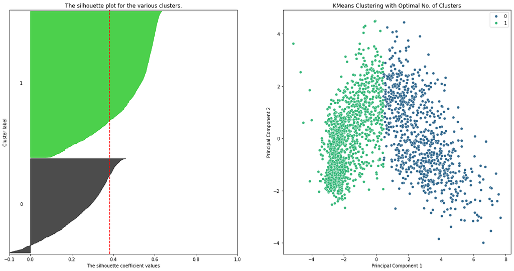

```python
k_values=range(2,11)
silhouette_scores={}

for k in k_values:
    kmeans=KMeans(n_clusters=k).fit(X_pca)
    labels=kmeans.labels_
    silhouette_scores[k]=silhouette_score(X_pca, labels)
    print(f"Silhouette score for k={k} is: {silhouette_scores[k]}")

optimal_k = max(silhouette_scores, key=silhouette_scores.get)
print(f"Optimal k: {optimal_k}")
print(f"Silhouette score for optimal k: {silhouette_scores[optimal_k]}")

cluster_model = KMeans(n_clusters=optimal_k)
kmeans_labels = cluster_model.fit_predict(X_pca)
marketing_updated['kmeans_Clusters']=kmeans_labels

# Perform K-means clustering with the optimal number of clusters
kmeans = KMeans(n_clusters=optimal_k, random_state=42)
cluster_labels = kmeans.fit_predict(X_pca)

# Silhouette plot
fig, ax = plt.subplots(1, 2, figsize=(20, 10))
ax[0].set_xlim([-0.1, 1])
ax[0].set_ylim([0, len(X_pca) + (optimal_k + 1) * 10])

# Compute the silhouette scores for each sample
sample_silhouette_values = silhouette_samples(X_pca, cluster_labels)

y_lower = 10
for i in range(optimal_k):
    ith_cluster_silhouette_values = sample_silhouette_values[cluster_labels == i]
    ith_cluster_silhouette_values.sort()

    size_cluster_i = ith_cluster_silhouette_values.shape[0]
    y_upper = y_lower + size_cluster_i

    color = plt.cm.nipy_spectral(float(i) / optimal_k)
    ax[0].fill_betweenx(np.arange(y_lower, y_upper), 0, ith_cluster_silhouette_values,
                     facecolor=color, edgecolor=color, alpha=0.7)

    ax[0].text(-0.05, y_lower + 0.5 * size_cluster_i, str(i))
    y_lower = y_upper + 10  # 10 for the 0 samples gap

ax[0].set_title("The silhouette plot for the various clusters.")
ax[0].set_xlabel("The silhouette coefficient values")
ax[0].set_ylabel("Cluster label")

# The vertical line for average silhouette score of all the values
ax[0].axvline(x=silhouette_scores[optimal_k], color="red", linestyle="--")
ax[0].set_yticks([])  # Clear the yaxis labels / ticks
ax[0].set_xticks([-0.1, 0, 0.2, 0.4, 0.6, 0.8, 1])

# scatterplot of the first two principal components
plt.subplot(1,2,2)
sns.scatterplot(x=X_pca[:, 0], y=X_pca[:, 1], hue=kmeans_labels, palette='viridis', legend='full')
plt.title('KMeans Clustering with Optimal No. of Clusters')
plt.xlabel('Principal Component 1')
plt.ylabel('Principal Component 2')
plt.show()
```

```python
segments_kmeans=marketing_updated.drop(['Clusters_4','Clusters_7'],axis=1).groupby('kmeans_Clusters')
for name, group in segments_kmeans:
    print(f"Segment 4: Cluster {name}")
    print(group.describe())
```

```
Segment 4: Cluster 0
              Income     Kidhome    Teenhome     Recency     MntWines  \
count     879.000000  879.000000  879.000000  879.000000   879.000000
mean    72226.189989    0.065984    0.422071   49.509670   606.559727
std     23943.612745    0.252939    0.534048   28.852221   315.573879
min      2447.000000    0.000000    0.000000    0.000000     1.000000
25%     63901.000000    0.000000    0.000000   25.000000   371.000000
50%     71613.000000    0.000000    0.000000   51.000000   561.000000
75%     79801.500000    0.000000    1.000000   73.000000   818.000000
max    666666.000000    2.000000    2.000000   99.000000  1493.000000

        MntFruits  MntMeatProducts  MntFishProducts  MntSweetProducts  \
count  879.000000       879.000000       879.000000        879.000000
mean    56.588168       366.189989        80.440273         58.343572
std     48.407285       248.372771        64.746717         50.290140
min      0.000000         3.000000         0.000000          0.000000
25%     20.000000       171.000000        29.000000         20.000000
50%     42.000000       305.000000        64.000000         43.000000
75%     83.000000       500.000000       120.000000         89.000000
max    199.000000      1725.000000       259.000000        263.000000

       MntGoldProds  ...  AcceptedCmp3  AcceptedCmp4  AcceptedCmp5  \
count    879.000000  ...    879.000000    879.000000    879.000000
mean      76.796359  ...      0.081911      0.133106      0.185438
std       61.605222  ...      0.274386      0.339882      0.388874
min        0.000000  ...      0.000000      0.000000      0.000000
25%       30.000000  ...      0.000000      0.000000      0.000000
50%       56.000000  ...      0.000000      0.000000      0.000000
75%      111.500000  ...      0.000000      0.000000      0.000000
max      362.000000  ...      1.000000      1.000000      1.000000

       AcceptedCmp1  AcceptedCmp2    Complain    Response         Age  \
count    879.000000    879.000000  879.000000  879.000000  879.000000
mean       0.155859      0.031854    0.007964    0.234357   55.939704
std        0.362928      0.175712    0.088934    0.423838   12.463606
min        0.000000      0.000000    0.000000    0.000000   28.000000
25%        0.000000      0.000000    0.000000    0.000000   47.000000
50%        0.000000      0.000000    0.000000    0.000000   56.000000
75%        0.000000      0.000000    0.000000    0.000000   66.000000
max        1.000000      1.000000    1.000000    1.000000  124.000000
```

[output cut: 49 more lines]

```
50%        0.000000       0.00000     0.000000     0.000000    52.000000
75%        0.000000       0.00000     0.000000     0.000000    61.000000
max        1.000000       1.00000     1.000000     1.000000   130.000000

       In_Relationship  kmeans_Clusters
count      1361.000000           1361.0
mean          0.656870              1.0
std           0.474929              0.0
min           0.000000              1.0
25%           0.000000              1.0
50%           1.000000              1.0
75%           1.000000              1.0
max           1.000000              1.0

[8 rows x 25 columns]
```

### Task 7 Interpretation -

**Comparison to Agglomerative Clustering:**

- The agglomerative clustering with 4 or 7 clusters (from the previous task) provided a more granular segmentation of the data. In contrast, k-means with the optimal number of clusters (2, in this case) suggests a broader, perhaps more generalizable segmentation.
- The k-means approach is likely to yield more spherical clusters due to the algorithm's nature, whereas agglomerative clustering doesn't assume any particular shape for clusters, which may be beneficial if the actual clusters are not spherical.

**Segment Analysis for K-Means, k=2:**

The KMeans has clustered customers into 2 segments, which have some interesting characteristics. Comparing the mean of features in the 2 clusters, it has segmented as follows:

1. Cluster A has mean income ~ 39k while Cluster B has mean income ~ 72k.
2. On average the households in Cluster A have more kids and teens compared to those in Cluster B.
3. The spending of Cluster A is significantly lower on all products compared to Cluster B.
4. Cluster A people have not accepted Coupon Deal in 1st attempt, while a lot more of Cluster B people did.

## Task 8 (10 points):

Show the results of a t-SNE analysis of the dataset. Experiment with a variety of perplexity values and explain your final choice. As with the previous questions, keep in mind that one of the goals of cluster analysis with this dataset is creating customer segments. Can you define customer segments by examining the characteristics of each cluster? How might you label the points in the t-SNE plot to show characteristics of each cluster?

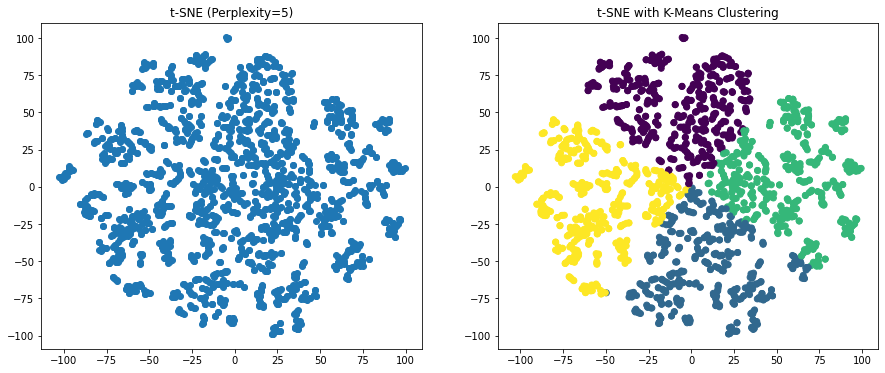

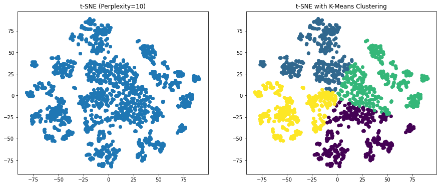

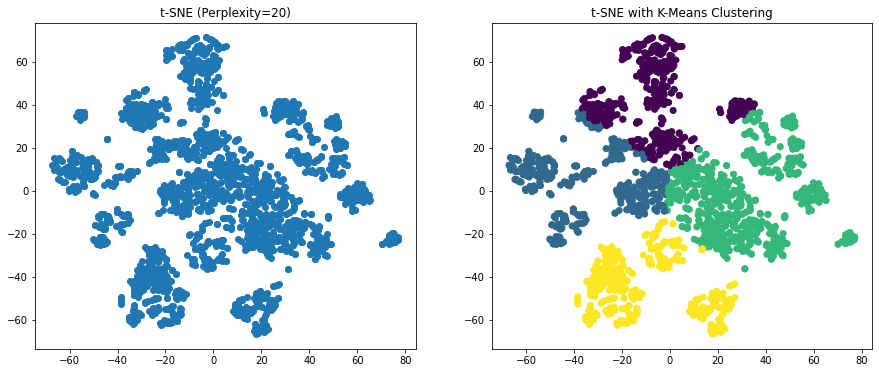

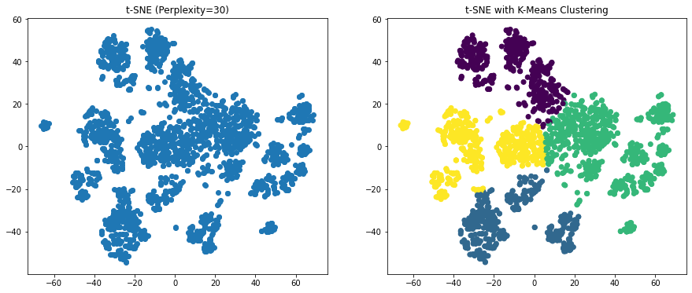

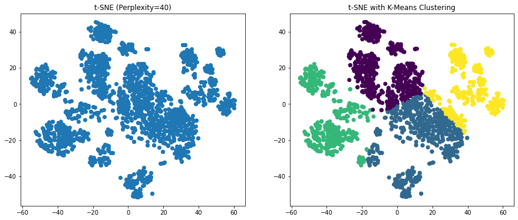

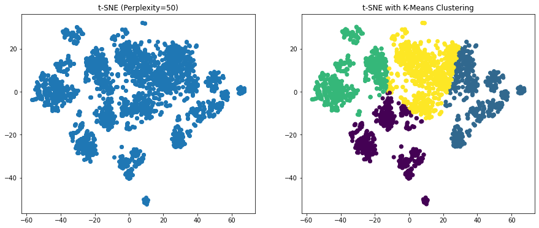

```python
# Create the PCA pipeline
X_transformed=preprocessor.fit_transform(marketing_updated)

perplexities = [5, 10, 20, 30, 40, 50]

for perplexity in perplexities:
    tsne = TSNE(n_components=2, perplexity=perplexity)
    X_tsne = tsne.fit_transform(X_transformed)

    n_clusters = 4 #Taken randomly
    kmeans = KMeans(n_clusters=n_clusters, random_state=42)
    cluster_labels = kmeans.fit_predict(X_tsne)

    plt.figure(figsize=(15,6))
    plt.subplot(1,2,1)
    plt.scatter(X_tsne[:, 0], X_tsne[:, 1])  # Scatter plot of t-SNE components
    plt.title(f"t-SNE (Perplexity={perplexity})")

    # Visualize the clusters
    plt.subplot(1,2,2)
    plt.scatter(X_tsne[:, 0], X_tsne[:, 1], c=cluster_labels, cmap='viridis')
    plt.title('t-SNE with K-Means Clustering')
    plt.show()

    plt.show()
```

### Task 8 Interpretation -

**Effect of Perplexity on Cluster Formation:**

- The t-SNE plots exhibit a clear transition in cluster formation as the perplexity value increases. At lower perplexity (5 and 10), the data points appear more dispersed, and several small clusters emerge. This indicates that t-SNE is capturing much of the local structure of the data. As the perplexity increases (20 to 50), the clusters become less fragmented and more cohesive, suggesting a shift from local to more global structure representation.

**Selection of Perplexity for Customer Segmentation:**

- The final selected perplexity of 30 for t-SNE leads to a balanced visualization where the clusters are neither too dispersed nor too aggregated. This middle ground can be indicative of a realistic customer segmentation where each cluster may represent a distinct customer profile.

### Use of Generative AI -

I used Generative AI in some markdown blocks to rephrase the initial textual observations drawn from the data analysis.

# NOTE

We **strongly** recommend restarting your kernel and running your complete notebook from top to bottom before submitting your work to Canvas in both HTML and IPYNB formats.